# Caribou Migration Portfolio Assignment

For the portfolio assignment I have decided to look at Caribou migration, specifically in Canada and Alaska. To do this, I have downloaded data from [Global Biodiversity Information Facility](https://www.gbif.org/) (GBIF) and have utilized EcoRegion data provided by UC Boulder. Caribou famously migrate hundreds of miles each year in search of food sources and breeding grounds. I will first present the code I used to create my interactive migration map and I will end with a discussion of existing research on caribou migration and relate it to my findings.

[figure not shown]

Caribou Migration. Source: Wikimedia

### Import Packages

```python
### import packages
import time ### time processing steps
import zipfile ### read and extract .zip folders
from getpass import getpass ### handles sensitive inputs like passwords and API tokens
from glob import glob ### function for finding file paths
import requests ### make requests to websites and web APIs

### GBIF packages
import pygbif.occurrences as occ ### get GBIF occurrence data
import pygbif.species as species ### deals with species names

### import additional packages you'll need
import pandas as pd
import os
import pathlib
import geopandas as gpd
import earthpy as et
import cartopy.crs as ccrs
import panel as pn
import holoviews as hv
import hvplot.pandas
import calendar
```

### Create a project folder and data directories

The code below creates a data directory for this project in the home directory which makes it reproducible for other users.

```python
### create data directory
data_dir2 = os.path.join(

    ### point to your home directory
    pathlib.Path.home(),

    ### nest the data in the folder where your assignments live
    'earth-analytics-course',
    'data',
    'caribou_data')

### make the directory
os.makedirs(data_dir2, exist_ok = True)

### define directory for the gbif data
caribou_dir = os.path.join(data_dir2, 'caribou')

### make the directory
os.makedirs(caribou_dir, exist_ok = True)
```

### Download Data from GBIF

GBIF provides open access species occurrence data from all over the world. Each occurrence includes the species, location, and date among other information.

Unfortunately, I was unable to successfully run the code provided to download my data. When I attended office hours we determined that there was an issue with my pygbif package which was preventing me from properly accessing the necessary taxonomy data. Luckily, GBIF provides a user friendly platform which allowed me to download my necessary data. I chose to download Caribou (Rangifer tarandus) data and filtered the data to include data only from United States and Canada and from 2010-2025. Initially, I only downloaded one year of data but discovered there were months with no observations so I chose to widen my filter to have more observations.

Once downloaded I moved my file into the directory I created in the code above.

The code below searches for the file in the directory and renames the file to be more descriptive.

```python
### search for the .csv file in the caribou directory
caribou_pattern = os.path.join(caribou_dir, '*.csv')

### find the extracted .csv file path
caribou_path = glob(caribou_pattern)[0]

### move files around
import shutil

### give the download a descriptive name
new_caribou_path = pathlib.Path(caribou_dir) / 'caribou-occurrences-2010-2025.csv'

### move file to descriptive path
shutil.move(caribou_path, new_caribou_path)
```

```
WindowsPath('C:/Users/GretaBinzen/earth-analytics-course/data/caribou_data/caribou/caribou-occurrences-2010-2025.csv')
```

### Load the GBIF data into Python

The code below loads the GBIF csv file into Python and converts it into a GeoDataFrame.

```python
### load the GBIF data
caribou_df = pd.read_csv(
    new_caribou_path,

    ### define value delimiter
    delimiter = '\t',

    ### set unique identifier as index
    index_col = 'gbifID',

    ### subset columns
    usecols = ['gbifID', 'decimalLatitude', 'decimalLongitude', 'month']
)

### convert to GeoDataFrame
caribou_gdf = (
    gpd.GeoDataFrame(
        caribou_df,

        ### set geometry for geodataframe from Lat/Lon of GBIF record
        geometry = gpd.points_from_xy(
            caribou_df.decimalLongitude,
            caribou_df.decimalLatitude
        ),

        ### set the coordinate reference system
        crs = "EPSG:4326"
    )

    ### select the desired columns
    [['month', 'geometry']]
)
```

### Load Ecoregion data

[Ecoregions] (https://www.nwf.org/en/Educational-Resources/Wildlife-Guide/Understanding-Conservation/ecoregions) are land areas that have similar climate, geography, soil, etc which we are able to download as shapefiles to help us see the movement of our occurrence data over time.

The code below downloads the Ecoregions data and loads the data to Python.

```python
### get url for ecoregions
ecoreg_url = ("https://storage.googleapis.com/"
       "teow2016/Ecoregions2017.zip")

### name the ecoregions directory name and file name
ecoreg_dir = os.path.join(caribou_dir, "ecoregions")

### make the ecoregions directory
os.makedirs(ecoreg_dir, exist_ok = True)

### join ecoregions shapefile path
ecoreg_path = os.path.join(ecoreg_dir, "ecoregions.shp")

### download the data once
if not os.path.exists(ecoreg_path):

    ### open file at url
    ecoreg_gdf = gpd.read_file(ecoreg_url)

    ### save it to the filepath as defined
    ecoreg_gdf.to_file(ecoreg_path)

### open up the ecoregions boundaries
ecoreg_gdf = gpd.read_file(ecoreg_path)
```

### Connect the GBIF observations to the ecoregions

In this section I combine the ecoregions and the observations **spatially** using a method called `.sjoin()`, which stands for spatial join.

For this data I use an inner join, which keeps only data where the ecoregion and occureence data overlap. This removes ecoregions that don't have any occurrence data as well as occurrence data that are outside of ecoregions (ie. in the ocean).

I also chose the spatial relationship of 'contains' meaning that the ecoregion must contain the lat/long of the occurrence data. Contains is a good predicate for comparing point data to polygon data.

```python
### join the gbif observations to the ecoregion polygons
caribou_ecoregion_gdf = (
    ecoreg_gdf

    ### match the CRS of the gbif data and the ecoregions
    .to_crs(caribou_gdf.crs)

    ### find ecoregion for each observation
    .sjoin(
        caribou_gdf,

        ### type of database join
        how = 'inner',

        ### spatial relationship
        predicate = 'contains')

    ### any additional manipulations you want to do
    ### (renaming columns, etc)
    [['OBJECTID', 'month']]

    ### rename columns to make ti easier to work with
    .rename(columns = {'OBJECTID': 'ecoregion'})

)
```

### Count the observations in each ecoregion each month

To see movement in Caribou over time we want to group the occurrence data by ecoregion and then by month. The code below counts the number of occurrence per ecoregion and month, removes single occurrence data (since it may have been an error), and then computes the mean occurrences by ecoregion and by month.

```python
### summarize the occurrences by ecoregion/month combination
caribou_occurrence_df = (
    caribou_ecoregion_gdf

    ### group by each ecoregion and month
    .groupby(['ecoregion', 'month'])

    ### and count the number of occurrences
    .agg(occurrences = ('ecoregion', 'count'))
)

### get rid of rare observations (which are possibly misidentifications)
caribou_occurrence_df = caribou_occurrence_df[caribou_occurrence_df.occurrences > 1]

### calculate the mean # observations by ecoregion
mean_caribou_occurrences_by_ecoregion = (
    caribou_occurrence_df
    .groupby('ecoregion')
    .mean()
)

### calculate the mean # observations by month
mean_caribou_occurrences_by_month = (
    caribou_occurrence_df
    .groupby('month')
        .mean()
)
```

### Normalize the observations

Divide occurrences by the mean occurrences by month and by ecoregion.

```python
### normalize by space and time for sampling effort
caribou_occurrence_df['norm_occurrences'] = (
    caribou_occurrence_df
    /mean_caribou_occurrences_by_ecoregion
    /mean_caribou_occurrences_by_month
)
```

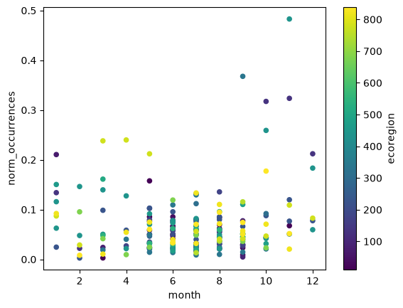

```python
### scatterplot
caribou_occurrence_df.reset_index().plot.scatter(
    x = 'month',
    y = 'norm_occurrences',
    c = 'ecoregion'
)
```

### Make an interactive map of GBIF observations

### Create a simplified GeoDataFrame for plotting

```python
### simplify the geometry to speed up processing
ecoreg_gdf.geometry = ecoreg_gdf.simplify(
    .05, preserve_topology = False
)

### change the CRS to Mercator for mapping
ecoreg_gdf = ecoreg_gdf.to_crs(ccrs.Mercator())

### check that the plot runs in a reasonable amount of time
ecoreg_gdf.hvplot(geo = True, crs = ccrs.Mercator())
```

### Map migration over time

The code below preps the data so that the column names are matching and then joins the occurrence data to the GeoDataFrame.

I then create my interactive map. I chose to set my xmin, ymin, xmax, and ymax to the extent of Canada and Alaska. For some reason my data was picking up occurrence data in other parts of the world that were distracting from my intention to map the Caribou migration across Alaska and Canada.

I then download my interactive map as an html file to my caribou directory.

```python
### prep the data, then combine the occurrence data with the ecoregions

### rename columns in ecoregID to match occurrence_df
ecoreg_gdf = ecoreg_gdf.rename(columns = {'OBJECTID': 'ecoregion'})

### make ecoreg ID the index for merge with occurrence_df
ecoreg_gdf = ecoreg_gdf.set_index('ecoregion')

### join the occurrences with the plotting GeoDataFrame
caribou_occurrence_gdf = ecoreg_gdf.join(caribou_occurrence_df)
```

```python
### activate panel and hvplot extensions you'll need for the interactive plot
pn.extension()
hv.extension("bokeh")
```

```python
# Approximate extent covering Alaska and Canada
xmin, ymin, xmax, ymax = -19942674, 5121984, -5858414, 20015000

### define the slider widget
slider = pn.widgets.DiscreteSlider(
    name = 'month',
    options = {calendar.month_name[i]: i for i in range(1, 13)}
)

### make the basemap tile object
carto_tiles = hv.Tiles(
    ("https://basemaps.cartocdn.com/rastertiles/voyager/{Z}/{X}/{Y}.png"
     "?key=cb1_446c_1_8946b413de0ace50f732dbf1"),
     name = "CARTO"
)

### plot the occurrence by month and ecoregion
caribou_migration_plot = (
    caribou_occurrence_gdf
    .hvplot(

        ### color by number of occurrences
        c = 'norm_occurrences',

        ### group by month
        groupby = 'month',

        ### set up for basemap tiles
        geo = True, crs = ccrs.Mercator(),

        # tiles = carto_tiles,
        tiles = carto_tiles,

        ### add a title
        title = "Interactive map of Caribou migration",

        ### set plot boundaries
        xlim = (xmin, xmax), ylim = (ymin, ymax),

        ### set height and width of map
        frame_height = 600,
        frame_width = 900,

        ### put the slider widget at the bottom of the map
        widget_location = 'bottom',

        ### if you want to see the legend, change this to true
        ### note that the values for the different colors vary month to month
        colorbar = True,

        ### label slider widget
        widgets = {'month': slider}
    )
)


## wrap plot with panel
caribou_interactive_migration_plot = pn.panel(caribou_migration_plot)

caribou_interactive_migration_plot

### make home for the map
map_path_carto = os.path.join(caribou_dir, "caribou_migration_map_carto.html")
map_path_carto

### export map
caribou_interactive_migration_plot.save(
    map_path_carto,
    embed = True,
    resources = "inline",
    )
caribou_interactive_migration_plot
```

```
WARNING:W-1005 (FIXED_SIZING_MODE): 'fixed' sizing mode requires width and height to be set: figure(id='c80c6387-dabf-47f3-9ecf-77cb3e23e177', ...)
```

[output not shown]

### [Interactive Map is linked here](https://gretabinzen.github.io/portfolio-posts/caribou-migration-map-carto.html).

### Wrap up

```python
%store caribou_df caribou_gdf ecoreg_gdf caribou_occurrence_df
```

```
Stored 'caribou_df' (DataFrame)
Stored 'caribou_gdf' (GeoDataFrame)
Stored 'ecoreg_gdf' (GeoDataFrame)
Stored 'caribou_occurrence_df' (DataFrame)
```

## Discussion

### Occurrence Data Shows Caribou Migration in Spring and Fall

For this project I mapped Caribou occurrence data over time. My map showed caribou occurrences concentrated in Central Canada and Southern Alaska in the winter months. The caribou occurrences spread out significantly in the spring and summer months with occurrence data shown in northern Alaska, Yukon Territory and even Greenland. At the same time there was still occurrence data in Central Canada and Southern Alaska in the summer months, indicating that not all caribou migrate significant distances. In the fall months, the occurrences concentrated back to Central Canada and Southern Alaska.

Existing research on caribou migration is well-aligned with the findings from the occurrence data. Caribou have the longest migration of any terrestrial species with some subspecies of caribou migrating over 2000 miles each year to travel from their winter calving grounds to their summer habitat. The primary reason for this migration is in search of nutritious food sources and to keep their young safe from predators. However, not all subspecies of caribou migrate which explains why there was occurrence data in Central Canada and Southern Alaska year-round. Follow-up maps could be created to show the migration of individual subspecies of caribou, particularly Grant's Caribou which is the subspecies with some of the longest migrations (Joly, 2018).

Among many challenges, Caribou migration is currently under threat by the proposed Ambler Industrial Mining Road which would run over 200 miles through Alaskan National Parks. This road would cut directly through the Western Arctic Caribou Herd’s migration corridor. Studies show that this road could have multiple impacts to the caribou including shifting the herd to the West (away from native communities that rely on Caribou as a food source) and also slow their migration, impacting their ability to get to food sources in a timely manner (Wilson, 2016).

**Bibliography**

Joly, K., Rasic , J., Mason, R., & Lukin, M. (2018, June 12). History, purpose, and status of Caribou Movements in northwest Alaska. National Parks Service. https://www.nps.gov/articles/aps-17-1-7.htm

Wilson, Ryan & Parrett, Lincoln & Joly, Kyle & Dau, Jim. (2016). Effects of roads on individual caribou movements during migration. Biological Conservation. 195. 2-8. 10.1016/j.biocon.2015.12.035.